# Assignment 5 - DESeq2

## 4. Diagnostic plot of the raw p-values for all genes

Using the same results tibble from the previous function, plot a histogram of the raw p-values for all of the genes discovered in the experiment. Avoid using the base ggplot2 theme and make sure to label any appropriate axes and components of the plot.

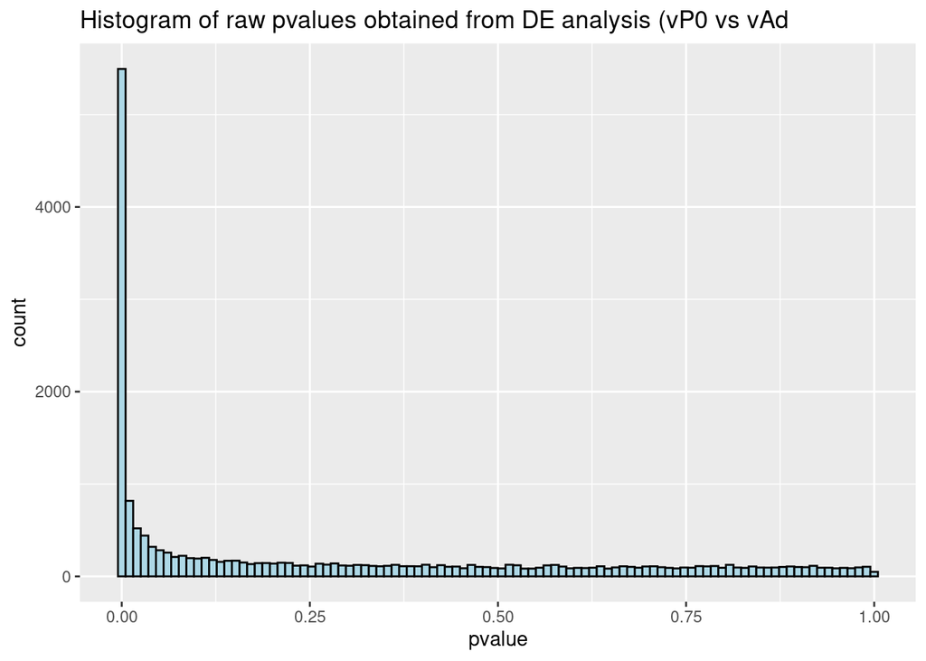

Distribution of unadjusted p-values from DESeq2 differential expression analysis comparing vAd and vP0 timepoints. The enrichment of p-values near zero indicates a large number of significantly differentially expressed genes between the two timepoints, with the remaining genes showing a uniform distribution consistent with the null hypothesis

## 5. Plotting the LogFoldChanges for differentially expressed genes

Using the results tibble, make a histogram of the Log2FoldChange values for all significant differentially expressed genes at a user-defined padj threshold and set this threshold to .10. Avoid using the base ggplot2 theme and make sure to label any appropriate axes and components of the plot.

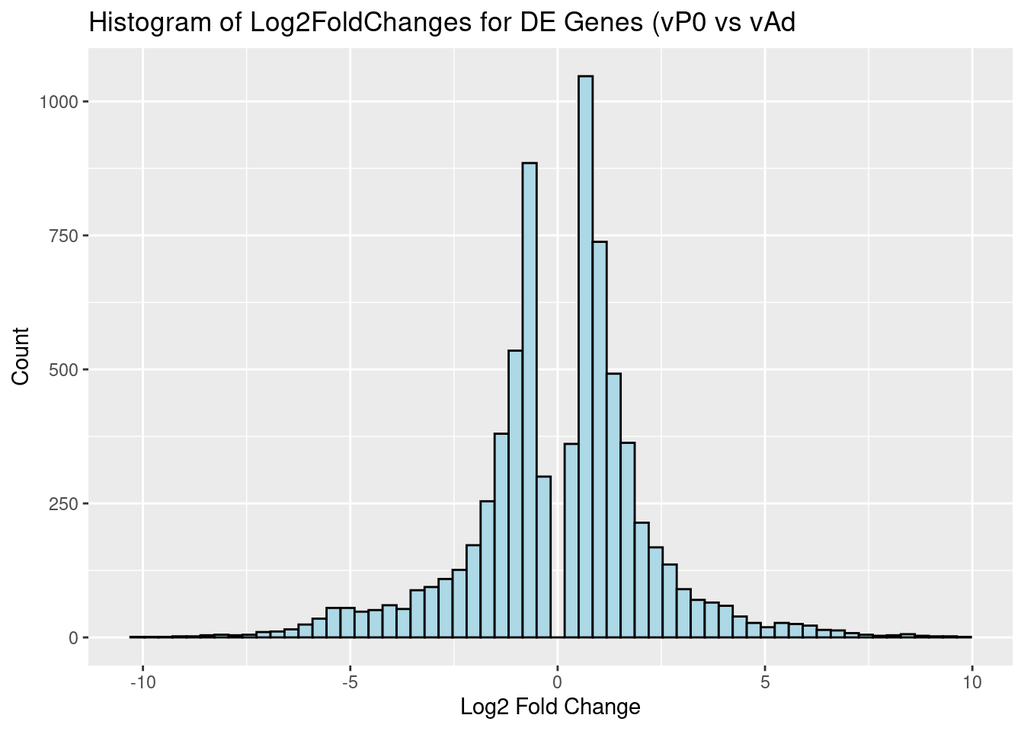

[output not shown]

## 6. Plotting the normalized counts of differentially expressed genes

Extract out the DESeq2 normalized counts (by size factors) for the top ten differentially expressed genes as ranked by ascending padj. Make a scatter / jitter plot of the counts and label each by their samplenames.

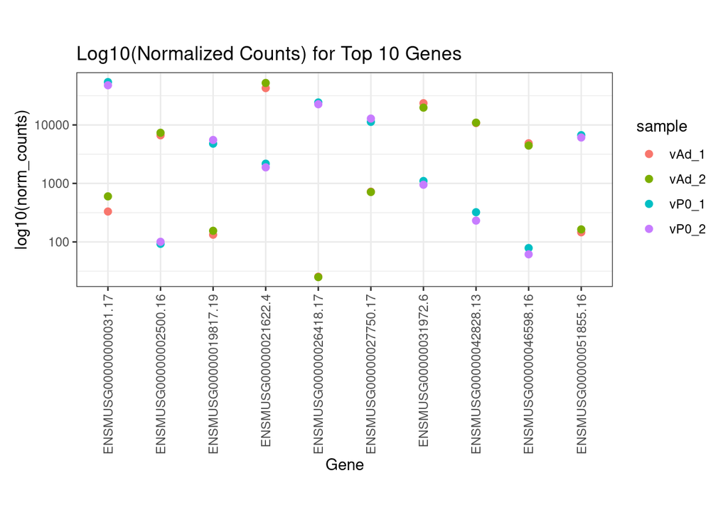

Normalized read counts for top 10 genes ranked by adjusted p-values across all four samples (vP0_1, vP0_2, vAd_1, vAd_2 on a log10 scale. Wide spread of normalized counts across samples for each gene reflects strong differential expression between vP0 and vAd timepoints

## 7. Volcano Plot to visualize differential expression results

Using the status column you generated in part 3, make a volcano plot of the DESeq2 results and color the points appropriately.

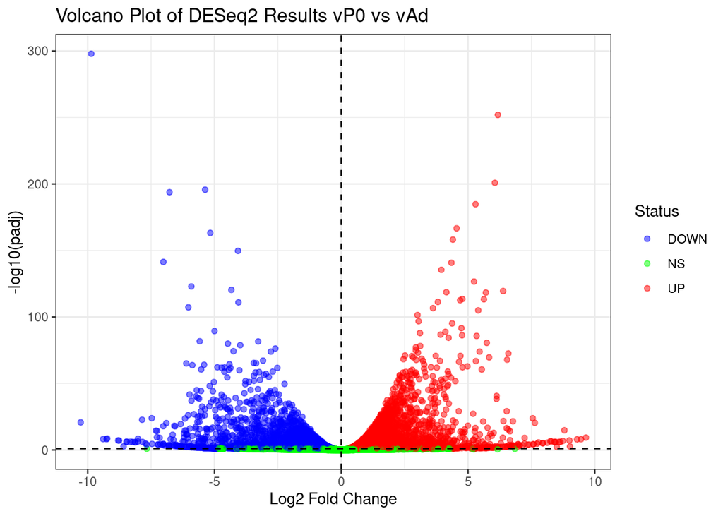

## 8. Running fgsea

This section will be split into two separate functions that will generated a ranked named list of genes and their log2FoldChange values and perform `fgsea()`, respectively. Please use the provided id2gene.txt file you containing matching ensembl ids and their corresponding gene symbol to add a column to your labeled results for the corresponding gene symbol. Then, use this new column and generate a named vector containing your gene symbols and their corresponding log2FC value ordered by log2FC descending. Make sure to use the gene symbols in place of their ensembl id in order to match the identifiers used in the GMT gene sets file.

```r
#first load in the id2gene.txt appropriately
#add a new column in your labeled results that matches IDs to symbols
#generate a named vector of symbols and log2FC values in descending order
rnk_list <- make_ranked_log2fc(annotated, 'data/id2gene.txt')
```

```r
#use head to display the top of the list
head(rnk_list)
```

```
##        Strit1          Inmt 2310015A16Rik       Gm49708           Pah
##      9.651319      9.455326      9.298171      9.021722      8.997306
##         mt-Ti
##      8.801921
```

```r
#use tail to display the bottom of the list
tail(rnk_list)
```

```
##       Cpa1      Bmp10      Troap    Or51af1      Tnni1       Dlk1
##  -8.798726  -9.230116  -9.251710  -9.392386  -9.859226 -10.275799
```

Perform a GSEA using a ranked list log2FoldChange values for all genes discovered in the DESeq2 results against the C2 Canonical Pathways gene set collection. As recommended, please set the minSize and maxSize parameters to 15 and 500, respectively. Before running fgsea, you will have to load the GMT pathways file in an appropriate format for `fgsea`. Otherwise, run fgsea using default parameters and the `fgsea()` function.

```
## # A tibble: 918 × 8
##    pathway                  pval     padj log2err     ES   NES  size leadingEdge
##    <chr>                   <dbl>    <dbl>   <dbl>  <dbl> <dbl> <int> <list>
##  1 REACTOME_CELL_CYCLE… 1.25e-21 1.15e-18   1.20  -0.615 -2.42   259 <chr [67]>
##  2 REACTOME_MITOTIC_SP… 1.27e-18 5.83e-16   1.11  -0.734 -2.61   107 <chr [32]>
##  3 REACTOME_AMPLIFICAT… 7.77e-17 2.38e-14   1.06  -0.752 -2.62    90 <chr [31]>
##  4 REACTOME_MITOTIC_PR… 3.11e-16 7.13e-14   1.04  -0.620 -2.37   187 <chr [45]>
##  5 REACTOME_RESOLUTION… 4.95e-16 9.08e-14   1.03  -0.700 -2.51   116 <chr [36]>
##  6 REACTOME_THE_CITRIC… 8.80e-16 1.35e-13   1.03   0.624  2.49   161 <chr [134]>
##  7 REACTOME_MITOTIC_ME… 1.41e-15 1.85e-13   1.02  -0.590 -2.31   218 <chr [41]>
##  8 REACTOME_SEPARATION… 4.67e-14 5.36e-12   0.965 -0.600 -2.30   180 <chr [36]>
##  9 REACTOME_RESPIRATOR… 9.69e-14 9.88e-12   0.955  0.684  2.57    95 <chr [75]>
## 10 REACTOME_RESPIRATOR… 1.34e-12 1.23e-10   0.910  0.637  2.44   117 <chr [102]>
## # ℹ 908 more rows
```

## 9. Plotting the top ten positive NES and top ten negative NES pathways

To make a quick visualization of these GSEA results, make a barchart for the pathways with the top ten most positive and top ten most negative NES scores. Color the bars by whether they have a positive or negative NES.

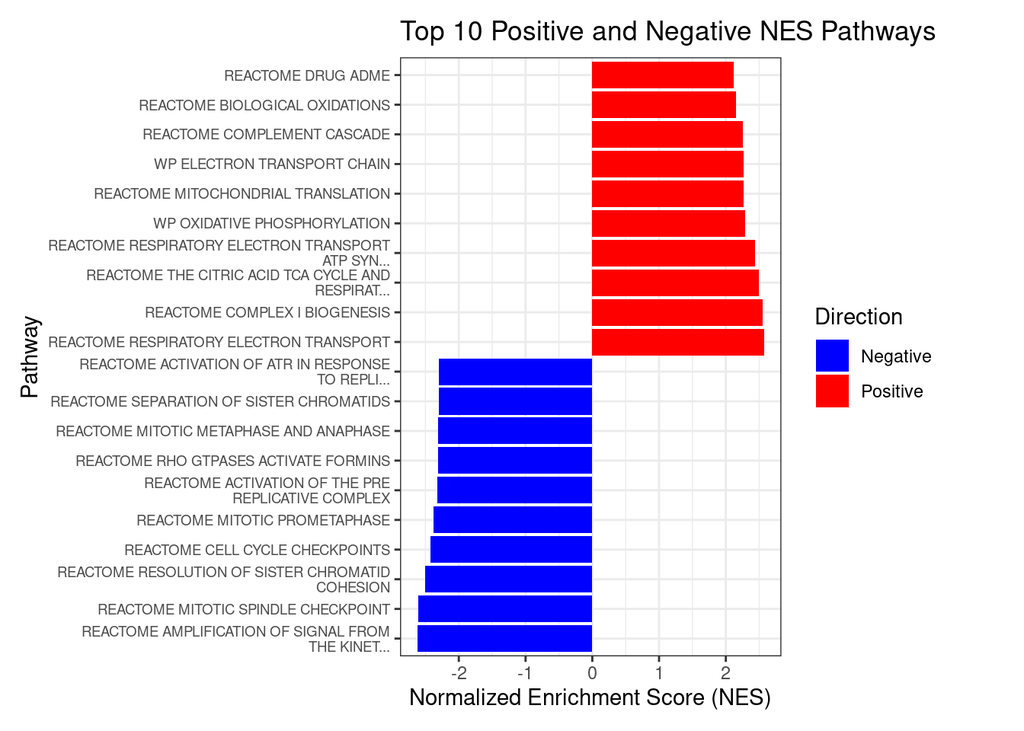

Top 10 positively and negatively enriched pathways from fgsea analysis with all pathways showing normalized enrichment scores (NES) of approximately 2 in magnitude. Positively enriched pathways (red) are predominantly related to cellular respiration and oxidative phosphorylation, suggesting upregulation of metabolic processes in vAd relative to vP0. Negatively enriched pathways (blue) are largely associated with cell division and the cell cycle, indicating downregulation of proliferative processes.